# Week 3 Short Answer Questions

## Corey McGinnis

Compiled on Wed Mar 8 15:25:01 2017.

## 5.1

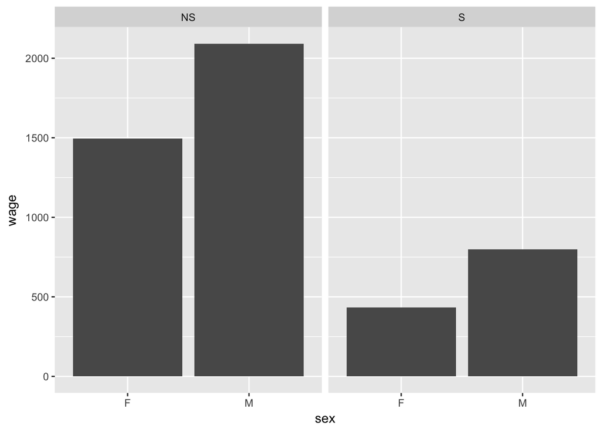

```r
ggplot(data=CPS85,aes(x=sex,y=wage ))+geom_bar(stat='identity',position='stack', width=.9)+ facet_wrap(~south,ncol=3)
```

# 5.2

```r
WorldMap(HappinessIndex,country,corruption)
```

```
## Mapping API still under development and may change in future releases.
```

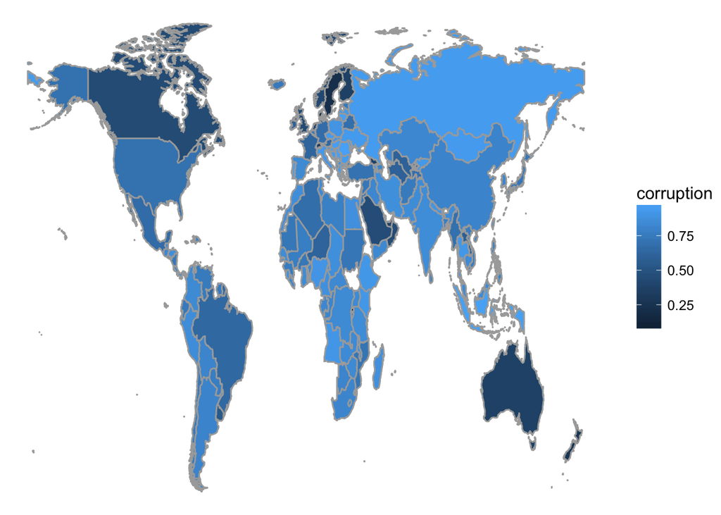

# 6.5

2. State and Polling Organization

# 6.6

4. Glyph: Rectangle. Graphical attribute: color and text

# 6.7

4. NYT poll probability for the Democratic Candidate

# 6.8

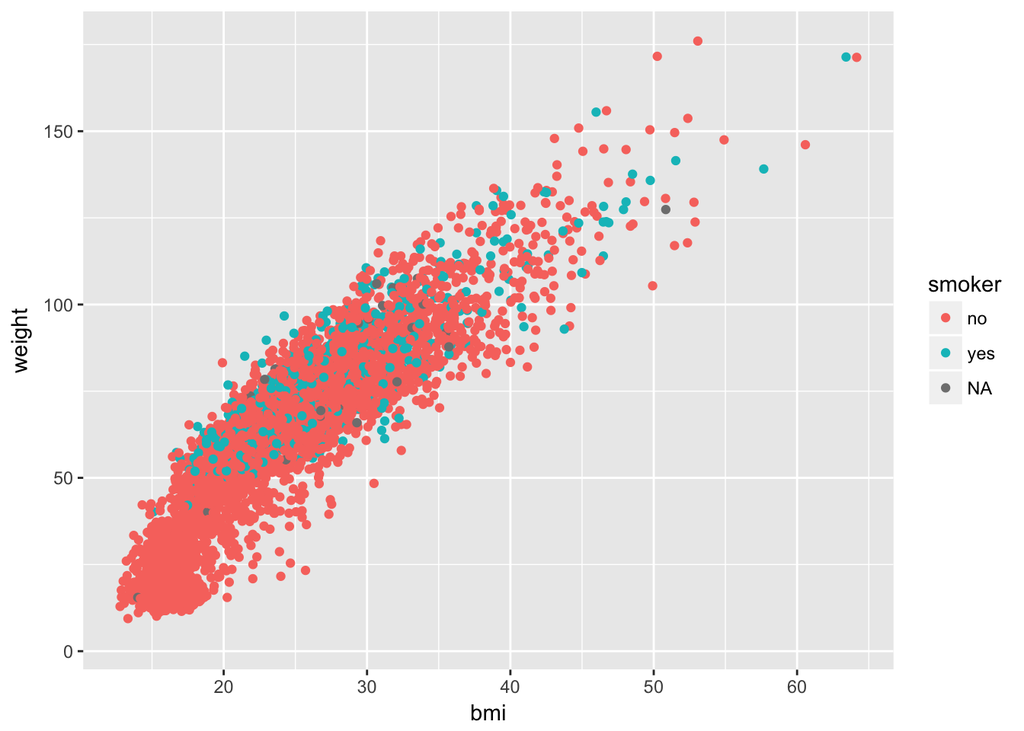

```r
Small <-
  NCHS %>%
  sample_n(size = 5000)

ggplot(data=Small,aes(x=bmi,y=weight))+geom_point()+aes(colour=smoker)
```

x-coord maps to bmi y-coord maps to weight color blue maps to smoker color red maps to non-smoker color grey maps to NA

# 7.1,

1. mean
2. mutate
3. desc
4. filter
5. group_by
6. summarise

# 7.4

1. Uses a case not a variable in group_by
2. Calls Tmp in summarize
3. doesn’t use %>%

# 7.5,

1. arrange(count)

```r
BabyNames %>%
  arrange(count)
```

```
##                    name sex count year
## 1                Adelle   F     5 1880
## 2                 Adina   F     5 1880
## 3              Adrienne   F     5 1880
## 4             Albertine   F     5 1880
## 5                  Alys   F     5 1880
## 6                   Ana   F     5 1880
## 7              Araminta   F     5 1880
## 8                Arthur   F     5 1880
## 9                Birtha   F     5 1880
## 10                Bulah   F     5 1880
## 11               Caddie   F     5 1880
## 12                Celie   F     5 1880
## 13            Charlotta   F     5 1880
## 14                Clair   F     5 1880
```

[output cut: 24986 more lines]

2. filter(sex == “F”)
3. filter(sex == “M”)
4. summarise(total = sum(count))
5. group_by(name, count) #7.7,
6. do not need to use BabyNames in groupby or summarise
7. never calls BabyNames
8. uses -> instead of %>%
9. statements and syntax are backwards

# 7.11,

1. number of patients of each sex and their average age
2. number of patients with each diagnosis, and the mean age of each diagnosis
3. number of patients with each diagnosis divided into the different sexes, mean age of each sex diagnosis
4. number of types of diagnosises at each age, average age of each age
5. number of people at each different age, and average age #7.12
1. n()
2. names
3. ??
4. library
5. group_by
6. sum